# Case study report for Childhood body size

09 July 2022

**Report for: Childhood body size (ukb-a-34)**

This case study report includes the results for Childhood body size, generated automatically using Rmarkdown.

The report is split into 3(+1) parts:

1. Mendelian randomization (MR) results for Childhood body size for all breast cancer outcomes (BCAC 2017 and 2020)
2. Overview of potential mediators identified from MR-EvE data; their validation with two-step and multivariable MR (MVMR)
3. Overview of potential mediators identified from literature-mined data; their validation with two-step, bidirectional, and MVMR
4. *Optional* validation of results with female-only exposure data (if available)
- Trait IDs in this report correspond to data available in [OpenGWAS](https://gwas.mrcieu.ac.uk/)
- BCAC 2017 outcomes names/IDs: Full sample (“Breast cancer”) `ieu-a-1126`, ER+ sample (“ER+ Breast cancer”)`ieu-a-1127`, ER- sample (“ER- Breast cancer”) `ieu-a-1128`
- MR analyses in this report were performed using TwoSampleMR and MVMR packages
- The two-sample MR estimates presented in this report were produced with inverse-variance weighted (IVW) or Wald ratio (for single SNP traits)

This report is a part of the publication *“Integrating Mendelian randomization and literature-mined evidence for breast cancer risk factors”* Vabistsevits et al 2022

# 1 Main analysis MR results

Childhood body size data details:

- Source: UK Biobank
- Sample size: > 450K
- nSNPs: 144
- Sample sex: mixed

Childhood body size was identified in MR-EvE search as having evidence of effect on breast cancer and validated with IVW MR method in BCAC 2017 and BCAC 2020 breast cancer outcomes:

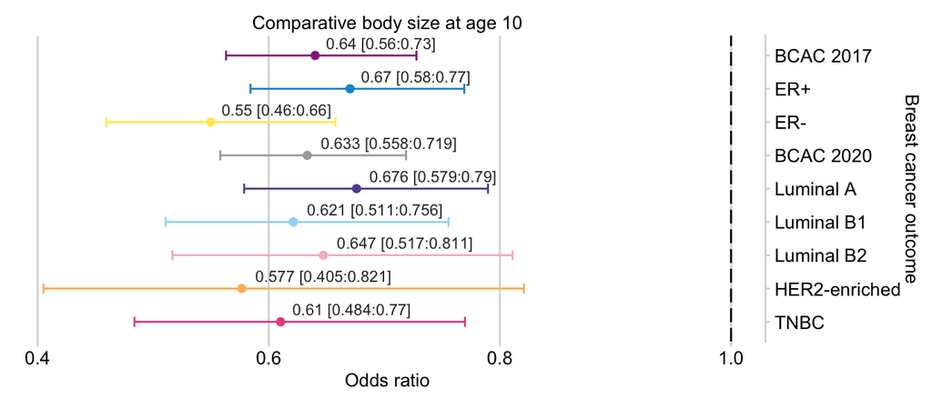

| exposure | outcome | IVW OR | pval | nsnp | Egger intercept < 0.05 | Heterogeneity Qpval < 0.05 |
| --- | --- | --- | --- | --- | --- | --- |
| Comparative body size at age 10 | BCAC 2017 | 0.64 [0.56:0.73] | 9.5e-12 | 144 | TRUE | TRUE |
| Comparative body size at age 10 | ER+ | 0.67 [0.58:0.77] | 1.2e-08 | 144 | TRUE | TRUE |
| Comparative body size at age 10 | ER- | 0.55 [0.46:0.66] | 6.4e-11 | 144 | TRUE | TRUE |
| Comparative body size at age 10 | BCAC 2020 | 0.633 [0.558:0.719] | 1.5e-12 | 129 | TRUE | TRUE |
| Comparative body size at age 10 | Luminal A | 0.676 [0.579:0.79] | 8.0e-07 | 129 | TRUE | TRUE |
| Comparative body size at age 10 | Luminal B1 | 0.621 [0.511:0.756] | 1.9e-06 | 129 | TRUE | FALSE |
| Comparative body size at age 10 | Luminal B2 | 0.647 [0.517:0.811] | 1.6e-04 | 129 | TRUE | FALSE |
| Comparative body size at age 10 | HER2-enriched | 0.577 [0.405:0.821] | 2.2e-03 | 129 | TRUE | TRUE |
| Comparative body size at age 10 | TNBC | 0.61 [0.484:0.77] | 3.1e-05 | 129 | TRUE | TRUE |

The full MR results and sensitivity analysis are available in Supplementary Data 2 and 3.

# 2 MR-EvE-mined mediators

By querying MR-EvE data for Childhood body size we identified 38 potential mediators. This analysis was done only for BCAC 2017 outcomes (full / ER+ / ER-), and only those that were affected in the main MR analysis: full , ER+ , ER- sample(s)

Below is a table of two-step MR results for each mediator, including *exposure -> mediator* and *mediator -> outcome*. The total effect of *exposure -> outcome* is available in the table above.

## 2.1 Two-step MR

**Full sample**: 33 potential mediators from MR-EvE

| exposure | outcome | mediator.id | mediator | exposure -> mediator (step1) beta_CI | nSNPs (step1) | mediator -> outcome (step2) OR_CI | nSNPs (step2) |
| --- | --- | --- | --- | --- | --- | --- | --- |
| Comparative body size at age 10 | BCAC 2017 | ukb-d-30770_irnt | IGF-1 | -0.22 [-0.29:-0.15] | 157 | 1.07 [1.01:1.13] | 318 |
| Comparative body size at age 10 | BCAC 2017 | ukb-d-30760_irnt | HDL cholesterol | -0.23 [-0.3:-0.16] | 157 | 1.09 [1.04:1.13] | 245 |
| Comparative body size at age 10 | BCAC 2017 | ukb-d-1418_3 | Milk type used: Skimmed | 0.09 [0.08:0.11] | 157 | 0.01 [0:0.35] | 3 |
| Comparative body size at age 10 | BCAC 2017 | ukb-b-3881 | Fresh fruit intake | 0.11 [0.08:0.13] | 157 | 0.64 [0.46:0.9] | 53 |
| Comparative body size at age 10 | BCAC 2017 | met-c-959 | Phospholipids in chylomicrons and largest VLDL particles | 0.17 [0.04:0.3] | 153 | 0.87 [0.82:0.92] | 8 |
| Comparative body size at age 10 | BCAC 2017 | met-c-951 | Phospholipids in very large VLDL | 0.2 [0.07:0.33] | 153 | 0.9 [0.85:0.95] | 9 |
| Comparative body size at age 10 | BCAC 2017 | met-c-950 | Concentration of very large VLDL particles | 0.24 [0.1:0.38] | 152 | 0.89 [0.85:0.94] | 8 |
| Comparative body size at age 10 | BCAC 2017 | met-c-931 | Phospholipids in small VLDL | 0.16 [0.03:0.29] | 153 | 0.93 [0.88:0.98] | 14 |
| Comparative body size at age 10 | BCAC 2017 | met-c-930 | Concentration of small VLDL particles | 0.19 [0.05:0.32] | 153 | 0.93 [0.88:0.97] | 15 |
| Comparative body size at age 10 | BCAC 2017 | met-c-929 | Total lipids in small VLDL | 0.18 [0.05:0.32] | 153 | 0.93 [0.88:0.98] | 14 |
| Comparative body size at age 10 | BCAC 2017 | met-c-928 | Free cholesterol in small VLDL | 0.16 [0.03:0.29] | 153 | 0.93 [0.88:0.97] | 14 |
| Comparative body size at age 10 | BCAC 2017 | met-c-915 | Triglycerides in medium VLDL | 0.23 [0.1:0.35] | 153 | 0.89 [0.86:0.93] | 13 |
| Comparative body size at age 10 | BCAC 2017 | met-c-914 | Phospholipids in medium VLDL | 0.2 [0.08:0.33] | 153 | 0.91 [0.87:0.96] | 15 |
| Comparative body size at age 10 | BCAC 2017 | met-c-911 | Free cholesterol in medium VLDL | 0.21 [0.08:0.33] | 153 | 0.92 [0.88:0.97] | 12 |
| Comparative body size at age 10 | BCAC 2017 | met-c-910 | Cholesterol esters in medium VLDL | 0.19 [0.06:0.32] | 153 | 0.93 [0.88:0.97] | 14 |
| Comparative body size at age 10 | BCAC 2017 | met-c-890 | Concentration of large VLDL particles | 0.18 [0.05:0.31] | 153 | 0.9 [0.86:0.94] | 10 |
| Comparative body size at age 10 | BCAC 2017 | met-c-888 | Free cholesterol in large VLDL | 0.18 [0.05:0.3] | 153 | 0.9 [0.87:0.94] | 11 |
| Comparative body size at age 10 | BCAC 2017 | met-c-887 | Cholesterol esters in large VLDL | 0.21 [0.08:0.35] | 153 | 0.9 [0.86:0.93] | 12 |
| Comparative body size at age 10 | BCAC 2017 | met-c-878 | Concentration of large HDL particles | -0.31 [-0.44:-0.19] | 153 | 1.05 [1.01:1.08] | 11 |
| Comparative body size at age 10 | BCAC 2017 | met-c-877 | Total lipids in large HDL | -0.32 [-0.44:-0.19] | 153 | 1.05 [1.01:1.09] | 11 |
| Comparative body size at age 10 | BCAC 2017 | met-c-875 | Cholesterol esters in large HDL | -0.31 [-0.43:-0.18] | 153 | 1.06 [1.02:1.11] | 13 |
| Comparative body size at age 10 | BCAC 2017 | ieu-a-99 | Hip circumference | 0.91 [0.78:1.05] | 124 | 0.56 [0.34:0.93] | 3 |
| Comparative body size at age 10 | BCAC 2017 | ieu-a-974 | Body mass index | 1.18 [1.08:1.29] | 122 | 0.74 [0.64:0.84] | 36 |
| Comparative body size at age 10 | BCAC 2017 | ieu-a-95 | Body mass index | 1.13 [1:1.26] | 124 | 0.67 [0.52:0.87] | 11 |
| Comparative body size at age 10 | BCAC 2017 | ieu-a-91 | Obesity class 2 | 3.63 [3.25:4.02] | 122 | 0.87 [0.83:0.92] | 10 |
| Comparative body size at age 10 | BCAC 2017 | ieu-a-85 | Extreme body mass index | 4.4 [3.91:4.88] | 117 | 0.87 [0.83:0.92] | 7 |
| Comparative body size at age 10 | BCAC 2017 | ieu-a-783 | Triglycerides | 0.26 [0.11:0.41] | 41 | 0.91 [0.85:0.98] | 27 |
| Comparative body size at age 10 | BCAC 2017 | ieu-a-780 | HDL cholesterol | -0.41 [-0.56:-0.26] | 41 | 1.08 [1.03:1.14] | 37 |
| Comparative body size at age 10 | BCAC 2017 | ieu-a-75 | Waist-to-hip ratio | 0.42 [0.34:0.5] | 122 | 0.78 [0.62:0.97] | 20 |
| Comparative body size at age 10 | BCAC 2017 | ieu-a-62 | Waist circumference | 0.97 [0.86:1.07] | 122 | 0.72 [0.59:0.87] | 17 |
| Comparative body size at age 10 | BCAC 2017 | ieu-a-51 | Hip circumference | 0.97 [0.86:1.07] | 122 | 0.73 [0.59:0.9] | 16 |
| Comparative body size at age 10 | BCAC 2017 | ieu-a-1096 | Childhood obesity | 3.97 [3.57:4.36] | 109 | 0.82 [0.76:0.88] | 4 |
| Comparative body size at age 10 | BCAC 2017 | ieu-a-107 | Weight | 1.06 [0.93:1.19] | 124 | 0.67 [0.48:0.95] | 10 |

**ER+ sample**: 32 potential mediators from MR-EvE

| exposure | outcome | mediator.id | mediator | exposure -> mediator (step1) beta_CI | nSNPs (step1) | mediator -> outcome (step2) OR_CI | nSNPs (step2) |
| --- | --- | --- | --- | --- | --- | --- | --- |
| Comparative body size at age 10 | ER+ | ukb-d-30770_irnt | IGF-1 | -0.22 [-0.29:-0.15] | 157 | 1.06 [1:1.13] | 318 |
| Comparative body size at age 10 | ER+ | ukb-d-30760_irnt | HDL cholesterol | -0.23 [-0.3:-0.16] | 157 | 1.09 [1.04:1.14] | 245 |
| Comparative body size at age 10 | ER+ | ukb-d-30630_irnt | Apoliprotein A | -0.2 [-0.26:-0.14] | 157 | 1.07 [1.01:1.12] | 222 |
| Comparative body size at age 10 | ER+ | ukb-d-1418_3 | Milk type used: Skimmed | 0.09 [0.08:0.11] | 157 | 0.01 [0:0.15] | 3 |
| Comparative body size at age 10 | ER+ | ukb-b-3881 | Fresh fruit intake | 0.11 [0.08:0.13] | 157 | 0.65 [0.44:0.95] | 53 |
| Comparative body size at age 10 | ER+ | ukb-a-269 | Impedance of whole body | -0.68 [-0.74:-0.61] | 157 | 1.15 [1.04:1.28] | 333 |
| Comparative body size at age 10 | ER+ | prot-b-71 | fatty acid binding protein 4 | 0.59 [0.27:0.92] | 128 | 1.03 [1:1.05] | 3 |
| Comparative body size at age 10 | ER+ | met-c-959 | Phospholipids in chylomicrons and largest VLDL particles | 0.17 [0.04:0.3] | 153 | 0.85 [0.8:0.91] | 8 |
| Comparative body size at age 10 | ER+ | met-c-950 | Concentration of very large VLDL particles | 0.24 [0.1:0.38] | 152 | 0.87 [0.82:0.92] | 8 |
| Comparative body size at age 10 | ER+ | met-c-931 | Phospholipids in small VLDL | 0.16 [0.03:0.29] | 153 | 0.92 [0.87:0.96] | 14 |
| Comparative body size at age 10 | ER+ | met-c-930 | Concentration of small VLDL particles | 0.19 [0.05:0.32] | 153 | 0.91 [0.87:0.96] | 15 |
| Comparative body size at age 10 | ER+ | met-c-929 | Total lipids in small VLDL | 0.18 [0.05:0.32] | 153 | 0.92 [0.87:0.96] | 14 |
| Comparative body size at age 10 | ER+ | met-c-928 | Free cholesterol in small VLDL | 0.16 [0.03:0.29] | 153 | 0.91 [0.87:0.96] | 14 |
| Comparative body size at age 10 | ER+ | met-c-915 | Triglycerides in medium VLDL | 0.23 [0.1:0.35] | 153 | 0.88 [0.84:0.93] | 13 |
| Comparative body size at age 10 | ER+ | met-c-914 | Phospholipids in medium VLDL | 0.2 [0.08:0.33] | 153 | 0.9 [0.86:0.94] | 15 |
| Comparative body size at age 10 | ER+ | met-c-911 | Free cholesterol in medium VLDL | 0.21 [0.08:0.33] | 153 | 0.91 [0.86:0.95] | 12 |
| Comparative body size at age 10 | ER+ | met-c-910 | Cholesterol esters in medium VLDL | 0.19 [0.06:0.32] | 153 | 0.91 [0.87:0.96] | 14 |
| Comparative body size at age 10 | ER+ | met-c-890 | Concentration of large VLDL particles | 0.18 [0.05:0.31] | 153 | 0.88 [0.84:0.93] | 10 |
| Comparative body size at age 10 | ER+ | met-c-888 | Free cholesterol in large VLDL | 0.18 [0.05:0.3] | 153 | 0.88 [0.84:0.93] | 11 |
| Comparative body size at age 10 | ER+ | met-c-887 | Cholesterol esters in large VLDL | 0.21 [0.08:0.35] | 153 | 0.89 [0.84:0.93] | 12 |
| Comparative body size at age 10 | ER+ | met-c-876 | Free cholesterol in large HDL | -0.34 [-0.46:-0.21] | 153 | 1.08 [1.02:1.14] | 15 |
| Comparative body size at age 10 | ER+ | met-c-875 | Cholesterol esters in large HDL | -0.31 [-0.43:-0.18] | 153 | 1.07 [1.02:1.13] | 13 |
| Comparative body size at age 10 | ER+ | ieu-a-99 | Hip circumference | 0.91 [0.78:1.05] | 124 | 0.59 [0.36:0.96] | 3 |
| Comparative body size at age 10 | ER+ | ieu-a-91 | Obesity class 2 | 3.63 [3.25:4.02] | 122 | 0.9 [0.84:0.96] | 10 |
| Comparative body size at age 10 | ER+ | ieu-a-85 | Extreme body mass index | 4.4 [3.91:4.88] | 117 | 0.89 [0.85:0.94] | 7 |
| Comparative body size at age 10 | ER+ | ieu-a-783 | Triglycerides | 0.26 [0.11:0.41] | 41 | 0.9 [0.83:0.98] | 27 |
| Comparative body size at age 10 | ER+ | ieu-a-780 | HDL cholesterol | -0.41 [-0.56:-0.26] | 41 | 1.08 [1.03:1.15] | 37 |
| Comparative body size at age 10 | ER+ | ieu-a-75 | Waist-to-hip ratio | 0.42 [0.34:0.5] | 122 | 0.77 [0.62:0.96] | 20 |
| Comparative body size at age 10 | ER+ | ieu-a-62 | Waist circumference | 0.97 [0.86:1.07] | 122 | 0.77 [0.63:0.94] | 17 |
| Comparative body size at age 10 | ER+ | ieu-a-51 | Hip circumference | 0.97 [0.86:1.07] | 122 | 0.79 [0.64:0.96] | 16 |
| Comparative body size at age 10 | ER+ | ieu-a-1096 | Childhood obesity | 3.97 [3.57:4.36] | 109 | 0.85 [0.78:0.93] | 4 |
| Comparative body size at age 10 | ER+ | ieu-a-109 | Waist-to-hip ratio | 0.43 [0.32:0.54] | 124 | 0.7 [0.56:0.88] | 4 |

**ER- sample:** 0 potential mediators from MR-EvE

| exposure | outcome | mediator.id | mediator | exposure -> mediator (step1) beta_CI | nSNPs (step1) | mediator -> outcome (step2) OR_CI | nSNPs (step2) |
| --- | --- | --- | --- | --- | --- | --- | --- |

## 2.2 MVMR

Next, we performed MVMR with potential mediators. In the table below, we include the total effect from univariable MR and the direct effect from MVMR accounted for each mediator. The mediator traits that disrupt the total effect are highlighted.

0 traits attenuate the effect of Childhood body size on **breast cancer (full sample)** (highlighted):

| exposure | outcome | mediator | Total effect exposure -> outcome | Exp SNPs (total) | Direct effect exposure -> outcome | Exp SNPs (direct) | Med SNPs (direct) | is_disrupted |
| --- | --- | --- | --- | --- | --- | --- | --- | --- |
| Comparative body size at age 10 | Breast cancer | IGF-1 | 0.64 [0.56:0.73] | 144 | 0.65 [0.57:0.73] | 150 | 305 | FALSE |
| Comparative body size at age 10 | Breast cancer | HDL cholesterol | 0.64 [0.56:0.73] | 144 | 0.64 [0.57:0.72] | 147 | 243 | FALSE |
| Comparative body size at age 10 | Breast cancer | Milk type used: Skimmed | 0.64 [0.56:0.73] | 144 | 0.7 [0.58:0.84] | 147 | 5 | FALSE |
| Comparative body size at age 10 | Breast cancer | Fresh fruit intake | 0.64 [0.56:0.73] | 144 | 0.66 [0.58:0.75] | 152 | 58 | FALSE |
| Comparative body size at age 10 | Breast cancer | Phospholipids in chylomicrons and largest VLDL particles | 0.64 [0.56:0.73] | 144 | 0.66 [0.58:0.75] | 142 | 8 | FALSE |
| Comparative body size at age 10 | Breast cancer | Phospholipids in very large VLDL | 0.64 [0.56:0.73] | 144 | 0.66 [0.58:0.75] | 142 | 9 | FALSE |
| Comparative body size at age 10 | Breast cancer | Concentration of very large VLDL particles | 0.64 [0.56:0.73] | 144 | 0.66 [0.58:0.75] | 141 | 8 | FALSE |
| Comparative body size at age 10 | Breast cancer | Phospholipids in small VLDL | 0.64 [0.56:0.73] | 144 | 0.65 [0.57:0.74] | 142 | 14 | FALSE |
| Comparative body size at age 10 | Breast cancer | Concentration of small VLDL particles | 0.64 [0.56:0.73] | 144 | 0.65 [0.57:0.74] | 142 | 15 | FALSE |
| Comparative body size at age 10 | Breast cancer | Total lipids in small VLDL | 0.64 [0.56:0.73] | 144 | 0.65 [0.57:0.74] | 142 | 14 | FALSE |
| Comparative body size at age 10 | Breast cancer | Free cholesterol in small VLDL | 0.64 [0.56:0.73] | 144 | 0.65 [0.57:0.74] | 142 | 14 | FALSE |
| Comparative body size at age 10 | Breast cancer | Triglycerides in medium VLDL | 0.64 [0.56:0.73] | 144 | 0.66 [0.58:0.75] | 142 | 13 | FALSE |
| Comparative body size at age 10 | Breast cancer | Phospholipids in medium VLDL | 0.64 [0.56:0.73] | 144 | 0.65 [0.58:0.74] | 142 | 15 | FALSE |
| Comparative body size at age 10 | Breast cancer | Free cholesterol in medium VLDL | 0.64 [0.56:0.73] | 144 | 0.65 [0.58:0.74] | 142 | 12 | FALSE |
| Comparative body size at age 10 | Breast cancer | Cholesterol esters in medium VLDL | 0.64 [0.56:0.73] | 144 | 0.65 [0.57:0.74] | 142 | 14 | FALSE |
| Comparative body size at age 10 | Breast cancer | Concentration of large VLDL particles | 0.64 [0.56:0.73] | 144 | 0.66 [0.58:0.74] | 142 | 10 | FALSE |
| Comparative body size at age 10 | Breast cancer | Free cholesterol in large VLDL | 0.64 [0.56:0.73] | 144 | 0.66 [0.58:0.74] | 142 | 11 | FALSE |
| Comparative body size at age 10 | Breast cancer | Cholesterol esters in large VLDL | 0.64 [0.56:0.73] | 144 | 0.66 [0.58:0.75] | 142 | 12 | FALSE |
| Comparative body size at age 10 | Breast cancer | Concentration of large HDL particles | 0.64 [0.56:0.73] | 144 | 0.65 [0.57:0.74] | 142 | 11 | FALSE |
| Comparative body size at age 10 | Breast cancer | Total lipids in large HDL | 0.64 [0.56:0.73] | 144 | 0.65 [0.57:0.74] | 142 | 11 | FALSE |
| Comparative body size at age 10 | Breast cancer | Cholesterol esters in large HDL | 0.64 [0.56:0.73] | 144 | 0.65 [0.58:0.74] | 142 | 13 | FALSE |
| Comparative body size at age 10 | Breast cancer | Hip circumference | 0.64 [0.56:0.73] | 144 | 0.6 [0.51:0.7] | 118 | 5 | FALSE |
| Comparative body size at age 10 | Breast cancer | Body mass index | 0.64 [0.56:0.73] | 144 | 0.61 [0.47:0.79] | 129 | 48 | FALSE |
| Comparative body size at age 10 | Breast cancer | Body mass index | 0.64 [0.56:0.73] | 144 | 0.65 [0.53:0.79] | 122 | 16 | FALSE |
| Comparative body size at age 10 | Breast cancer | Obesity class 2 | 0.64 [0.56:0.73] | 144 | 0.71 [0.54:0.93] | 120 | 17 | FALSE |
| Comparative body size at age 10 | Breast cancer | Extreme body mass index | 0.64 [0.56:0.73] | 144 | 0.71 [0.54:0.93] | 114 | 11 | FALSE |
| Comparative body size at age 10 | Breast cancer | Triglycerides | 0.64 [0.56:0.73] | 144 | 0.53 [0.43:0.66] | 38 | 28 | FALSE |
| Comparative body size at age 10 | Breast cancer | HDL cholesterol | 0.64 [0.56:0.73] | 144 | 0.53 [0.44:0.65] | 38 | 38 | FALSE |
| Comparative body size at age 10 | Breast cancer | Waist-to-hip ratio | 0.64 [0.56:0.73] | 144 | 0.6 [0.51:0.69] | 114 | 22 | FALSE |
| Comparative body size at age 10 | Breast cancer | Waist circumference | 0.64 [0.56:0.73] | 144 | 0.65 [0.51:0.83] | 120 | 24 | FALSE |
| Comparative body size at age 10 | Breast cancer | Hip circumference | 0.64 [0.56:0.73] | 144 | 0.64 [0.5:0.82] | 120 | 24 | FALSE |
| Comparative body size at age 10 | Breast cancer | Childhood obesity | 0.64 [0.56:0.73] | 144 | 0.57 [0.41:0.78] | 116 | 8 | FALSE |
| Comparative body size at age 10 | Breast cancer | Weight | 0.64 [0.56:0.73] | 144 | 0.57 [0.46:0.7] | 119 | 12 | FALSE |

0 traits attenuate the effect of Childhood body size on **ER+ breast cancer** (highlighted):

| exposure | outcome | mediator | Total effect exposure -> outcome | Exp SNPs (total) | Direct effect exposure -> outcome | Exp SNPs (direct) | Med SNPs (direct) | is_disrupted |
| --- | --- | --- | --- | --- | --- | --- | --- | --- |
| Comparative body size at age 10 | ER+ Breast cancer | IGF-1 | 0.67 [0.58:0.77] | 144 | 0.67 [0.59:0.77] | 150 | 305 | FALSE |
| Comparative body size at age 10 | ER+ Breast cancer | HDL cholesterol | 0.67 [0.58:0.77] | 144 | 0.67 [0.59:0.76] | 147 | 243 | FALSE |
| Comparative body size at age 10 | ER+ Breast cancer | Apoliprotein A | 0.67 [0.58:0.77] | 144 | 0.67 [0.59:0.77] | 149 | 211 | FALSE |
| Comparative body size at age 10 | ER+ Breast cancer | Milk type used: Skimmed | 0.67 [0.58:0.77] | 144 | 0.75 [0.62:0.91] | 147 | 5 | FALSE |
| Comparative body size at age 10 | ER+ Breast cancer | Fresh fruit intake | 0.67 [0.58:0.77] | 144 | 0.69 [0.6:0.8] | 152 | 58 | FALSE |
| Comparative body size at age 10 | ER+ Breast cancer | Impedance of whole body | 0.67 [0.58:0.77] | 144 | 0.65 [0.55:0.77] | 167 | 370 | FALSE |
| Comparative body size at age 10 | ER+ Breast cancer | fatty acid binding protein 4 | 0.67 [0.58:0.77] | 144 | 0.65 [0.56:0.76] | 118 | 3 | FALSE |
| Comparative body size at age 10 | ER+ Breast cancer | Phospholipids in chylomicrons and largest VLDL particles | 0.67 [0.58:0.77] | 144 | 0.69 [0.6:0.79] | 142 | 8 | FALSE |
| Comparative body size at age 10 | ER+ Breast cancer | Concentration of very large VLDL particles | 0.67 [0.58:0.77] | 144 | 0.69 [0.6:0.79] | 141 | 8 | FALSE |
| Comparative body size at age 10 | ER+ Breast cancer | Phospholipids in small VLDL | 0.67 [0.58:0.77] | 144 | 0.68 [0.59:0.78] | 142 | 14 | FALSE |
| Comparative body size at age 10 | ER+ Breast cancer | Concentration of small VLDL particles | 0.67 [0.58:0.77] | 144 | 0.68 [0.59:0.78] | 142 | 15 | FALSE |
| Comparative body size at age 10 | ER+ Breast cancer | Total lipids in small VLDL | 0.67 [0.58:0.77] | 144 | 0.68 [0.59:0.78] | 142 | 14 | FALSE |
| Comparative body size at age 10 | ER+ Breast cancer | Free cholesterol in small VLDL | 0.67 [0.58:0.77] | 144 | 0.68 [0.59:0.78] | 142 | 14 | FALSE |
| Comparative body size at age 10 | ER+ Breast cancer | Triglycerides in medium VLDL | 0.67 [0.58:0.77] | 144 | 0.69 [0.6:0.79] | 142 | 13 | FALSE |
| Comparative body size at age 10 | ER+ Breast cancer | Phospholipids in medium VLDL | 0.67 [0.58:0.77] | 144 | 0.68 [0.6:0.78] | 142 | 15 | FALSE |
| Comparative body size at age 10 | ER+ Breast cancer | Free cholesterol in medium VLDL | 0.67 [0.58:0.77] | 144 | 0.68 [0.6:0.78] | 142 | 12 | FALSE |
| Comparative body size at age 10 | ER+ Breast cancer | Cholesterol esters in medium VLDL | 0.67 [0.58:0.77] | 144 | 0.68 [0.59:0.78] | 142 | 14 | FALSE |
| Comparative body size at age 10 | ER+ Breast cancer | Concentration of large VLDL particles | 0.67 [0.58:0.77] | 144 | 0.69 [0.6:0.79] | 142 | 10 | FALSE |
| Comparative body size at age 10 | ER+ Breast cancer | Free cholesterol in large VLDL | 0.67 [0.58:0.77] | 144 | 0.69 [0.6:0.79] | 142 | 11 | FALSE |
| Comparative body size at age 10 | ER+ Breast cancer | Cholesterol esters in large VLDL | 0.67 [0.58:0.77] | 144 | 0.69 [0.6:0.79] | 142 | 12 | FALSE |
| Comparative body size at age 10 | ER+ Breast cancer | Free cholesterol in large HDL | 0.67 [0.58:0.77] | 144 | 0.68 [0.6:0.79] | 142 | 15 | FALSE |
| Comparative body size at age 10 | ER+ Breast cancer | Cholesterol esters in large HDL | 0.67 [0.58:0.77] | 144 | 0.68 [0.6:0.79] | 142 | 13 | FALSE |
| Comparative body size at age 10 | ER+ Breast cancer | Hip circumference | 0.67 [0.58:0.77] | 144 | 0.65 [0.55:0.77] | 118 | 5 | FALSE |
| Comparative body size at age 10 | ER+ Breast cancer | Obesity class 2 | 0.67 [0.58:0.77] | 144 | 0.69 [0.52:0.91] | 120 | 17 | FALSE |
| Comparative body size at age 10 | ER+ Breast cancer | Extreme body mass index | 0.67 [0.58:0.77] | 144 | 0.7 [0.53:0.94] | 114 | 11 | FALSE |
| Comparative body size at age 10 | ER+ Breast cancer | Triglycerides | 0.67 [0.58:0.77] | 144 | 0.61 [0.48:0.77] | 38 | 28 | FALSE |
| Comparative body size at age 10 | ER+ Breast cancer | HDL cholesterol | 0.67 [0.58:0.77] | 144 | 0.6 [0.48:0.74] | 38 | 38 | FALSE |
| Comparative body size at age 10 | ER+ Breast cancer | Waist-to-hip ratio | 0.67 [0.58:0.77] | 144 | 0.64 [0.54:0.75] | 114 | 22 | FALSE |
| Comparative body size at age 10 | ER+ Breast cancer | Waist circumference | 0.67 [0.58:0.77] | 144 | 0.67 [0.52:0.87] | 120 | 24 | FALSE |
| Comparative body size at age 10 | ER+ Breast cancer | Hip circumference | 0.67 [0.58:0.77] | 144 | 0.66 [0.51:0.86] | 120 | 24 | FALSE |
| Comparative body size at age 10 | ER+ Breast cancer | Childhood obesity | 0.67 [0.58:0.77] | 144 | 0.58 [0.42:0.81] | 116 | 8 | FALSE |
| Comparative body size at age 10 | ER+ Breast cancer | Waist-to-hip ratio | 0.67 [0.58:0.77] | 144 | 0.65 [0.55:0.77] | 116 | 5 | FALSE |

0 traits attenuate the effect of Childhood body size on **ER- breast cancer** (highlighted):

| exposure | outcome | mediator | Total effect exposure -> outcome | Exp SNPs (total) | Direct effect exposure -> outcome | Exp SNPs (direct) | Med SNPs (direct) | is_disrupted |
| --- | --- | --- | --- | --- | --- | --- | --- | --- |

# 3 Literature-mined mediators

We searched literature-mined relationships in EpiGraphDB for Childhood body size and breast cancer and used literature-overlap method to identify potential intermediates between the two. The identified intermediates are tested as potential mediaotrs in this section.

## 3.1 Summary

Childhood body size literature space contains:

- 1255 unique triples of terms
- 962 unique pairs of terms

## 3.2 Literature overlap Sankey plot

This is a Sankey plot of literature overlap between Childhood body size and breast cancer. See the subset versions and explore filters in a separate app: https://mvab.shinyapps.io/literature_overlap_sankey/

[interactive chart not shown]

## 3.3 Matching literature terms to GWAS traits

Childhood body size and breast cancer literature space overlap identified:

- 114 unique literature terms
- 57 terms are available as GWAS traits in OpenGWAS (table below)
- 40 (33 unique) traits have >=1 genome-wide significant SNPs (instruments for MR) (highlighted in the table)

| Literature term | Matching GWAS in OpenGWAS | GWAS ID | nSNPs p < 5x10e8 |
| --- | --- | --- | --- |
| Adiponectin | ieu-a-1 | Adiponectin | 14 |
| AGT | prot-c-3484_60_2 | Angiotensinogen | 0 |
| AKT1 | prot-a-70 | RAC-alpha/beta/gamma serine/threonine-protein kinase | 1 |
| Alanine Transaminase | prot-a-1264 | Alanine aminotransferase 1 | 0 |
| Alanine Transaminase | ebi-a-GCST004940 | Alanine transaminase levels | 0 |
| Alanine Transaminase | prot-c-3709_4_2 | ALT | 0 |
| Alanine Transaminase | ukb-d-30620_irnt | Alanine aminotransferase | 207 |
| C-reactive protein | ieu-b-35 | C-Reactive protein level | 57 |
| C-reactive protein | ebi-a-GCST005067 | C-reactive protein levels | 0 |
| C-reactive protein | prot-a-670 | C-reactive protein | 4 |
| C-reactive protein | ukb-d-30710_irnt | C-reactive protein | 210 |
| CDKN1A | prot-a-497 | Cyclin-dependent kinase inhibitor 3 | 0 |
| Cortisone | met-a-354 | Cortisone | 1 |
| CSNK1A1 | prot-a-695 | Casein kinase II subunit alpha | 0 |
| CSNK1A1 | prot-c-3427_63_2 | CSK21 | 0 |
| CSNK1A1 | prot-a-697 | Casein kinase II 2-alpha:2-beta heterotetramer | 2 |
| E-Selectin | prot-c-3470_1_2 | sE-Selectin | 0 |
| E-Selectin | prot-a-2665 | E-selectin | 2 |
| E-Selectin | prot-b-77 | selectin E | 1 |
| EGFR | prot-a-908 | Epidermal growth factor | 1 |
| Endothelin-1 | prot-a-892 | Endothelin-2 | 3 |
| ERBB2 | prot-c-2616_23_18 | ERBB2 | 0 |
| estradiol | ieu-b-4872 | Oestradiol | 1 |
| Estrogen Receptors | prot-c-2945_25_1 | ER | 0 |
| FABP4 | prot-a-1013 | Fatty acid-binding protein, adipocyte | 0 |
| FABP4 | prot-a-1014 | Fatty acid-binding protein, epidermal | 0 |
| FABP4 | prot-a-1012 | Fatty acid-binding protein, heart | 0 |
| FABP4 | prot-a-1011 | Fatty acid-binding protein, liver | 1 |
| FABP4 | prot-b-71 | fatty acid binding protein 4 | 3 |
| Ferritin | prot-a-1148 | Ferritin | 3 |

[output cut: 57 more lines]

## 3.4 Two-step MR (step 2)

We performed two-step MR for 40 traits with >=1 instruments (highlighted in table above):

- Adiponectin
- RAC-alpha/beta/gamma serine/threonine-protein kinase
- Alanine aminotransferase
- C-Reactive protein level
- C-reactive protein
- Cortisone
- Casein kinase II 2-alpha:2-beta heterotetramer
- E-selectin
- selectin E
- Epidermal growth factor
- Endothelin-2
- Oestradiol
- Fatty acid-binding protein, liver
- fatty acid binding protein 4
- Ferritin
- Fibronectin type III domain-containing protein 5
- Glycoprotein acetyls
- Growth hormone receptor
- Histone deacetylase 8
- Intercellular adhesion molecule 1
- IGF-1
- Interleukin-10
- Keratin, type I cytoskeletal 17
- Kynurenine
- Leptin receptor
- Nicotinamide phosphoribosyltransferase
- Obesity
- Osteocalcin
- Proline
- Melanocortin-2 receptor accessory protein
- Resistin
- Sex hormone binding globulin (SHBG)
- Total Testosterone
- Bioavailable Testosterone
- Thyrotropin-releasing hormone
- Tumor necrosis factor
- TNF receptor superfamily member 11b
- Tumor necrosis factor receptor superfamily member 11B

Out of these traits, 8 had evidence of effect on breast cancer (so could be considered further as potential mediators):

- selectin E
- IGF-1
- Total Testosterone
- Bioavailable Testosterone
- Ferritin
- C-reactive protein
- Epidermal growth factor
- fatty acid binding protein 4

**Mediator -> outcome (step2) MR results** for the traits with evidence of effect:

| exposure | id.exposure | outcome | OR_CI | nsnp |
| --- | --- | --- | --- | --- |
| selectin E | prot-b-77 | Breast cancer | 0.95 [0.93:0.97] | 1 |
| IGF-1 | ukb-d-30770_irnt | Breast cancer | 1.07 [1.01:1.13] | 318 |
| Total Testosterone | ieu-b-4864 | Breast cancer | 1.14 [1.06:1.23] | 108 |
| Bioavailable Testosterone | ieu-b-4869 | Breast cancer | 1.12 [1.04:1.2] | 115 |
| selectin E | prot-b-77 | ER- Breast cancer | 0.96 [0.93:0.99] | 1 |
| Ferritin | prot-a-1148 | ER- Breast cancer | 1.05 [1:1.1] | 3 |
| C-reactive protein | prot-a-670 | ER+ Breast cancer | 1.07 [1.02:1.13] | 3 |
| selectin E | prot-b-77 | ER+ Breast cancer | 0.95 [0.93:0.97] | 1 |
| Epidermal growth factor | prot-a-908 | ER+ Breast cancer | 0.94 [0.88:0.99] | 1 |
| fatty acid binding protein 4 | prot-b-71 | ER+ Breast cancer | 1.03 [1:1.05] | 3 |
| IGF-1 | ukb-d-30770_irnt | ER+ Breast cancer | 1.07 [1.01:1.13] | 318 |
| Total Testosterone | ieu-b-4864 | ER+ Breast cancer | 1.19 [1.09:1.3] | 108 |
| Bioavailable Testosterone | ieu-b-4869 | ER+ Breast cancer | 1.17 [1.09:1.26] | 115 |

## 3.5 Bidirectional MR (exp/med) (step1)

We next performed bidirectional MR to to establish the direction of the effect between the intermediate and the risk factor and identify the traits that are affected by the risk factor (i.e. likely mediator relationship) [**Exposure -> mediator (step1 of two-step MR)**] and the other way around (i.e. potential confounder relationship).

The table below highlights the relationships with evidence of effect.

Potential mediators: **IGF-1, Bioavailable Testosterone, fatty acid binding protein 4** (traits affect by Childhood body size)

| exposure | id.exposure | outcome | id.outcome | beta_CI | effect_direction | nsnp | effect |
| --- | --- | --- | --- | --- | --- | --- | --- |
| Comparative body size at age 10 | ukb-a-34 | selectin E | prot-b-77 | 0.1 [-0.23:0.42] | overlaps null | 128 | term trait as mediator |
| selectin E | prot-b-77 | Comparative body size at age 10 | ukb-a-34 | 0 [0:0.01] | overlaps null | 1 | term trait as confounder |
| Comparative body size at age 10 | ukb-a-34 | IGF-1 | ukb-d-30770_irnt | -0.22 [-0.29:-0.15] | negative | 157 | term trait as mediator |
| IGF-1 | ukb-d-30770_irnt | Comparative body size at age 10 | ukb-a-34 | -0.02 [-0.04:0] | negative | 319 | term trait as confounder |
| Comparative body size at age 10 | ukb-a-34 | Total Testosterone | ieu-b-4864 | 0.01 [-0.05:0.06] | overlaps null | 157 | term trait as mediator |
| Total Testosterone | ieu-b-4864 | Comparative body size at age 10 | ukb-a-34 | 0 [-0.02:0.02] | overlaps null | 104 | term trait as confounder |
| Comparative body size at age 10 | ukb-a-34 | Bioavailable Testosterone | ieu-b-4869 | 0.12 [0.05:0.18] | positive | 157 | term trait as mediator |
| Bioavailable Testosterone | ieu-b-4869 | Comparative body size at age 10 | ukb-a-34 | 0 [-0.02:0.02] | overlaps null | 117 | term trait as confounder |
| Comparative body size at age 10 | ukb-a-34 | Ferritin | prot-a-1148 | -0.06 [-0.34:0.22] | overlaps null | 154 | term trait as mediator |
| Ferritin | prot-a-1148 | Comparative body size at age 10 | ukb-a-34 | 0 [-0.01:0.01] | overlaps null | 3 | term trait as confounder |
| Comparative body size at age 10 | ukb-a-34 | C-reactive protein | prot-a-670 | 0.2 [-0.08:0.48] | overlaps null | 154 | term trait as mediator |
| C-reactive protein | prot-a-670 | Comparative body size at age 10 | ukb-a-34 | 0 [-0.01:0.01] | overlaps null | 3 | term trait as confounder |
| Comparative body size at age 10 | ukb-a-34 | Epidermal growth factor | prot-a-908 | -0.09 [-0.38:0.2] | overlaps null | 154 | term trait as mediator |
| Epidermal growth factor | prot-a-908 | Comparative body size at age 10 | ukb-a-34 | 0.01 [0:0.03] | overlaps null | 1 | term trait as confounder |
| Comparative body size at age 10 | ukb-a-34 | fatty acid binding protein 4 | prot-b-71 | 0.59 [0.27:0.92] | positive | 128 | term trait as mediator |
| fatty acid binding protein 4 | prot-b-71 | Comparative body size at age 10 | ukb-a-34 | 0 [-0.01:0] | overlaps null | 3 | term trait as confounder |

## 3.6 MVMR

For the identified potential mediators we perform MVMR with the known affected outcomes. The table below shows the total effect of exposure (Childhood body size) and each mediator, and their direct effects from MVMR analysis together.

The highlighted rows indicate when the direct effect overlaps the null.

| # | exposure/mediator | outcome | total effect (MR) | total effect direction | SNPs in total | direct effect (MVMR) | direct effect direction | SNPs in direct |
| --- | --- | --- | --- | --- | --- | --- | --- | --- |
| 1 |  |  |  |  |  |  |  |  |
|  | Comparative body size at age 10 | Breast cancer | 0.64 [0.56:0.73] | negative | 144 | 0.63 [0.55:0.71] | negative | 146 |
|  | Bioavailable Testosterone | Breast cancer | 1.12 [1.04:1.2] | positive | 115 | 1.13 [1.05:1.21] | positive | 112 |
| 2 |  |  |  |  |  |  |  |  |
|  | Comparative body size at age 10 | ER+ Breast cancer | 0.67 [0.58:0.77] | negative | 144 | 0.65 [0.57:0.75] | negative | 146 |
|  | Bioavailable Testosterone | ER+ Breast cancer | 1.17 [1.09:1.26] | positive | 115 | 1.19 [1.1:1.28] | positive | 112 |
| 3 |  |  |  |  |  |  |  |  |
|  | Comparative body size at age 10 | ER+ Breast cancer | 0.67 [0.58:0.77] | negative | 144 | 0.65 [0.56:0.76] | negative | 118 |
|  | fatty acid binding protein 4 | ER+ Breast cancer | 1.03 [1:1.05] | positive | 3 | 1.02 [0.99:1.05] | overlaps null | 3 |
| 4 |  |  |  |  |  |  |  |  |
|  | Comparative body size at age 10 | Breast cancer | 0.64 [0.56:0.73] | negative | 144 | 0.65 [0.57:0.73] | negative | 150 |
|  | IGF-1 | Breast cancer | 1.07 [1.01:1.13] | positive | 318 | 1.04 [0.99:1.1] | overlaps null | 305 |
| 5 |  |  |  |  |  |  |  |  |
|  | Comparative body size at age 10 | ER+ Breast cancer | 0.67 [0.58:0.77] | negative | 144 | 0.67 [0.59:0.77] | negative | 150 |
|  | IGF-1 | ER+ Breast cancer | 1.07 [1.01:1.13] | positive | 318 | 1.04 [0.98:1.11] | overlaps null | 305 |

# 4 (Optional): sensitivity analysis with female only data

This section is an optional sensitivity analysis, and is only run where external female-only data is available for the given exposure.

Childhood body size sensitivity analysis data details:

- Source: UK Biobank
- Sample size: 246K
- nSNPs: 115
- Sample sex: female

## 4.1 Two-step MR (step 2)

Effect on breast cancer from female-only data of Childhood body size

| exposure | outcome | OR_CI | effect_direction | nsnp |
| --- | --- | --- | --- | --- |
| Comparative body size at age 10 | Breast cancer | 0.66 [0.58:0.76] | negative | 102 |
| Comparative body size at age 10 | ER+ Breast cancer | 0.7 [0.61:0.82] | negative | 102 |
| Comparative body size at age 10 | ER- Breast cancer | 0.58 [0.48:0.7] | negative | 102 |

## 4.2 Bidirectional MR (exp/med) (step1) (female-only)

Testing on all literature intermediates and potential mediators from MR-EvE. An empty row indicates that no instruments were available to perform the analysis.

Potential mediators from female-only Childhood body size analysis: IGF-1, HDL cholesterol, Milk type used: Skimmed, Phospholipids in very large VLDL, Concentration of very large VLDL particles, Concentration of small VLDL particles, Total lipids in small VLDL, Triglycerides in medium VLDL, Free cholesterol in medium VLDL, Phospholipids in medium VLDL, Cholesterol esters in medium VLDL, Free cholesterol in large VLDL, Concentration of large VLDL particles, Cholesterol esters in large VLDL, Cholesterol esters in large HDL, Total lipids in large HDL, Concentration of large HDL particles, HDL cholesterol, Triglycerides, Fresh fruit intake, Apoliprotein A, fatty acid binding protein 4, Free cholesterol in large HDL, Bioavailable Testosterone

| exposure | id.exposure | outcome | id.outcome | beta_CI | effect_direction | nsnp | effect |
| --- | --- | --- | --- | --- | --- | --- | --- |
| Comparative body size at age 10 | 1fWtbt | IGF-1 | ukb-d-30770_irnt | -0.2 [-0.29:-0.11] | negative | 110 | term trait as mediator |
| IGF-1 | ukb-d-30770_irnt | Comparative body size at age 10 | 1fWtbt | -0.03 [-0.04:-0.01] | negative | 349 | term trait as confounder |
| Comparative body size at age 10 | 1fWtbt | HDL cholesterol | ukb-d-30760_irnt | -0.21 [-0.29:-0.14] | negative | 110 | term trait as mediator |
| HDL cholesterol | ukb-d-30760_irnt | Comparative body size at age 10 | 1fWtbt | -0.02 [-0.04:-0.01] | negative | 266 | term trait as confounder |
| Comparative body size at age 10 | 1fWtbt | Milk type used: Skimmed | ukb-d-1418_3 | 0.08 [0.06:0.1] | positive | 110 | term trait as mediator |
| Milk type used: Skimmed | ukb-d-1418_3 | Comparative body size at age 10 | 1fWtbt | 3.65 [1.35:5.96] | positive | 4 | term trait as confounder |
| Comparative body size at age 10 | 1fWtbt | Phospholipids in chylomicrons and largest VLDL particles | met-c-959 | 0.14 [0:0.27] | overlaps null | 110 | term trait as mediator |
| Phospholipids in chylomicrons and largest VLDL particles | met-c-959 | Comparative body size at age 10 | 1fWtbt | 0.03 [0:0.06] | overlaps null | 8 | term trait as confounder |
| Comparative body size at age 10 | 1fWtbt | Phospholipids in very large VLDL | met-c-951 | 0.16 [0.02:0.3] | positive | 110 | term trait as mediator |
| Phospholipids in very large VLDL | met-c-951 | Comparative body size at age 10 | 1fWtbt | 0.02 [0:0.04] | overlaps null | 9 | term trait as confounder |
| Comparative body size at age 10 | 1fWtbt | Concentration of very large VLDL particles | met-c-950 | 0.22 [0.06:0.37] | positive | 108 | term trait as mediator |
| Concentration of very large VLDL particles | met-c-950 | Comparative body size at age 10 | 1fWtbt | 0.02 [-0.01:0.04] | overlaps null | 8 | term trait as confounder |
| Comparative body size at age 10 | 1fWtbt | Concentration of small VLDL particles | met-c-930 | 0.15 [0.02:0.29] | positive | 110 | term trait as mediator |
| Concentration of small VLDL particles | met-c-930 | Comparative body size at age 10 | 1fWtbt | 0.02 [-0.01:0.04] | overlaps null | 15 | term trait as confounder |
| Comparative body size at age 10 | 1fWtbt | Free cholesterol in small VLDL | met-c-928 | 0.12 [-0.01:0.25] | overlaps null | 110 | term trait as mediator |
| Free cholesterol in small VLDL | met-c-928 | Comparative body size at age 10 | 1fWtbt | 0.01 [0:0.03] | overlaps null | 14 | term trait as confounder |
| Comparative body size at age 10 | 1fWtbt | Phospholipids in small VLDL | met-c-931 | 0.12 [-0.02:0.25] | overlaps null | 110 | term trait as mediator |
| Phospholipids in small VLDL | met-c-931 | Comparative body size at age 10 | 1fWtbt | 0.01 [-0.01:0.03] | overlaps null | 14 | term trait as confounder |
| Comparative body size at age 10 | 1fWtbt | Total lipids in small VLDL | met-c-929 | 0.15 [0.01:0.29] | positive | 110 | term trait as mediator |
| Total lipids in small VLDL | met-c-929 | Comparative body size at age 10 | 1fWtbt | 0.01 [-0.01:0.03] | overlaps null | 14 | term trait as confounder |
| Comparative body size at age 10 | 1fWtbt | Triglycerides in medium VLDL | met-c-915 | 0.17 [0.04:0.29] | positive | 110 | term trait as mediator |
| Triglycerides in medium VLDL | met-c-915 | Comparative body size at age 10 | 1fWtbt | 0.02 [0:0.05] | positive | 13 | term trait as confounder |
| Comparative body size at age 10 | 1fWtbt | Free cholesterol in medium VLDL | met-c-911 | 0.16 [0.03:0.29] | positive | 110 | term trait as mediator |
| Free cholesterol in medium VLDL | met-c-911 | Comparative body size at age 10 | 1fWtbt | 0.01 [-0.01:0.03] | overlaps null | 12 | term trait as confounder |
| Comparative body size at age 10 | 1fWtbt | Phospholipids in medium VLDL | met-c-914 | 0.16 [0.04:0.29] | positive | 110 | term trait as mediator |
| Phospholipids in medium VLDL | met-c-914 | Comparative body size at age 10 | 1fWtbt | 0.02 [0:0.04] | overlaps null | 15 | term trait as confounder |
| Comparative body size at age 10 | 1fWtbt | Cholesterol esters in medium VLDL | met-c-910 | 0.14 [0:0.28] | positive | 110 | term trait as mediator |
| Cholesterol esters in medium VLDL | met-c-910 | Comparative body size at age 10 | 1fWtbt | 0.01 [-0.01:0.03] | overlaps null | 14 | term trait as confounder |
| Comparative body size at age 10 | 1fWtbt | Free cholesterol in large VLDL | met-c-888 | 0.15 [0.01:0.28] | positive | 110 | term trait as mediator |
| Free cholesterol in large VLDL | met-c-888 | Comparative body size at age 10 | 1fWtbt | 0.02 [0:0.04] | positive | 11 | term trait as confounder |
| Comparative body size at age 10 | 1fWtbt | Concentration of large VLDL particles | met-c-890 | 0.14 [0:0.28] | positive | 110 | term trait as mediator |
| Concentration of large VLDL particles | met-c-890 | Comparative body size at age 10 | 1fWtbt | 0.01 [-0.01:0.03] | overlaps null | 10 | term trait as confounder |
| Comparative body size at age 10 | 1fWtbt | Cholesterol esters in large VLDL | met-c-887 | 0.18 [0.05:0.32] | positive | 110 | term trait as mediator |
| Cholesterol esters in large VLDL | met-c-887 | Comparative body size at age 10 | 1fWtbt | 0.02 [-0.01:0.04] | overlaps null | 12 | term trait as confounder |
| Comparative body size at age 10 | 1fWtbt | Cholesterol esters in large HDL | met-c-875 | -0.22 [-0.36:-0.09] | negative | 110 | term trait as mediator |
| Cholesterol esters in large HDL | met-c-875 | Comparative body size at age 10 | 1fWtbt | -0.01 [-0.02:0] | negative | 14 | term trait as confounder |
| Comparative body size at age 10 | 1fWtbt | Total lipids in large HDL | met-c-877 | -0.22 [-0.36:-0.09] | negative | 110 | term trait as mediator |
| Total lipids in large HDL | met-c-877 | Comparative body size at age 10 | 1fWtbt | -0.01 [-0.02:0.01] | overlaps null | 12 | term trait as confounder |
| Comparative body size at age 10 | 1fWtbt | Concentration of large HDL particles | met-c-878 | -0.22 [-0.35:-0.09] | negative | 110 | term trait as mediator |
| Concentration of large HDL particles | met-c-878 | Comparative body size at age 10 | 1fWtbt | -0.01 [-0.02:0.01] | overlaps null | 12 | term trait as confounder |
| Comparative body size at age 10 | 1fWtbt | HDL cholesterol | ieu-a-780 | -0.33 [-0.51:-0.14] | negative | 29 | term trait as mediator |
| HDL cholesterol | ieu-a-780 | Comparative body size at age 10 | 1fWtbt | -0.01 [-0.02:0.01] | overlaps null | 42 | term trait as confounder |
| Comparative body size at age 10 | 1fWtbt | Triglycerides | ieu-a-783 | 0.22 [0.03:0.41] | positive | 29 | term trait as mediator |
| Triglycerides | ieu-a-783 | Comparative body size at age 10 | 1fWtbt | 0.02 [-0.01:0.04] | overlaps null | 27 | term trait as confounder |
| Comparative body size at age 10 | 1fWtbt | Fresh fruit intake | ukb-b-3881 | 0.09 [0.06:0.12] | positive | 111 | term trait as mediator |
| Fresh fruit intake | ukb-b-3881 | Comparative body size at age 10 | 1fWtbt | 0.36 [0.13:0.59] | positive | 53 | term trait as confounder |
| Comparative body size at age 10 | 1fWtbt | Apoliprotein A | ukb-d-30630_irnt | -0.19 [-0.26:-0.12] | negative | 110 | term trait as mediator |
| Apoliprotein A | ukb-d-30630_irnt | Comparative body size at age 10 | 1fWtbt | -0.02 [-0.03:0] | negative | 241 | term trait as confounder |
| Comparative body size at age 10 | 1fWtbt | fatty acid binding protein 4 | prot-b-71 | 0.58 [0.25:0.91] | positive | 98 | term trait as mediator |
| fatty acid binding protein 4 | prot-b-71 | Comparative body size at age 10 | 1fWtbt | 0 [-0.01:0.01] | overlaps null | 3 | term trait as confounder |
| Comparative body size at age 10 | 1fWtbt | Free cholesterol in large HDL | met-c-876 | -0.25 [-0.39:-0.11] | negative | 110 | term trait as mediator |
| Free cholesterol in large HDL | met-c-876 | Comparative body size at age 10 | 1fWtbt | -0.01 [-0.03:0] | overlaps null | 16 | term trait as confounder |
| Comparative body size at age 10 | 1fWtbt | selectin E | prot-b-77 | 0.03 [-0.33:0.38] | overlaps null | 98 | term trait as mediator |
|  |  |  |  |  |  |  | term trait as confounder |
| Comparative body size at age 10 | 1fWtbt | Total Testosterone | ieu-b-4864 | -0.01 [-0.06:0.04] | overlaps null | 110 | term trait as mediator |
| Total Testosterone | ieu-b-4864 | Comparative body size at age 10 | 1fWtbt | 0 [-0.03:0.02] | overlaps null | 109 | term trait as confounder |
| Comparative body size at age 10 | 1fWtbt | Bioavailable Testosterone | ieu-b-4869 | 0.09 [0.02:0.16] | positive | 110 | term trait as mediator |
| Bioavailable Testosterone | ieu-b-4869 | Comparative body size at age 10 | 1fWtbt | 0 [-0.02:0.02] | overlaps null | 121 | term trait as confounder |
| Comparative body size at age 10 | 1fWtbt | Ferritin | prot-a-1148 | 0.09 [-0.2:0.37] | overlaps null | 110 | term trait as mediator |
| Ferritin | prot-a-1148 | Comparative body size at age 10 | 1fWtbt | 0 [-0.01:0.01] | overlaps null | 3 | term trait as confounder |
| Comparative body size at age 10 | 1fWtbt | C-reactive protein | prot-a-670 | 0.16 [-0.13:0.45] | overlaps null | 110 | term trait as mediator |
| C-reactive protein | prot-a-670 | Comparative body size at age 10 | 1fWtbt | 0.01 [0:0.02] | overlaps null | 4 | term trait as confounder |
| Comparative body size at age 10 | 1fWtbt | Epidermal growth factor | prot-a-908 | 0.03 [-0.3:0.36] | overlaps null | 110 | term trait as mediator |
|  |  |  |  |  |  |  | term trait as confounder |

## 4.3 MVMR

For the identified potential mediators we perform MVMR with the known affected outcomes. The table below shows the total effect of exposure ( Childhood body size ) and each mediator, and their direct effects from MVMR analysis together.

The highlighted rows indicate when the direct effect overlaps the null.

| # | exposure/mediator | outcome | total effect (MR) | total effect direction | SNPs in total | direct effect (MVMR) | direct effect direction | SNPs in direct |
| --- | --- | --- | --- | --- | --- | --- | --- | --- |
| 1 |  |  |  |  |  |  |  |  |
|  | Comparative body size at age 10 | Breast cancer | 0.66 [0.58:0.76] | negative | 102 | 0.57 [0.47:0.68] | negative | 27 |
|  | HDL cholesterol | Breast cancer |  |  |  | 1.08 [1.02:1.15] | positive | 38 |
| 2 |  |  |  |  |  |  |  |  |
|  | Comparative body size at age 10 | ER+ Breast cancer | 0.7 [0.61:0.82] | negative | 102 | 0.63 [0.51:0.77] | negative | 27 |
|  | HDL cholesterol | ER+ Breast cancer |  |  |  | 1.09 [1.02:1.16] | positive | 38 |
| 3 |  |  |  |  |  |  |  |  |
|  | Comparative body size at age 10 | ER- Breast cancer | 0.58 [0.48:0.7] | negative | 102 | 0.44 [0.33:0.6] | negative | 27 |
|  | HDL cholesterol | ER- Breast cancer |  |  |  | 1.11 [1:1.22] | positive | 38 |
| 4 |  |  |  |  |  |  |  |  |
|  | Comparative body size at age 10 | Breast cancer | 0.66 [0.58:0.76] | negative | 102 | 0.57 [0.47:0.71] | negative | 28 |
|  | Triglycerides | Breast cancer |  |  |  | 0.9 [0.84:0.98] | negative | 28 |
| 5 |  |  |  |  |  |  |  |  |
|  | Comparative body size at age 10 | ER+ Breast cancer | 0.7 [0.61:0.82] | negative | 102 | 0.64 [0.51:0.82] | negative | 28 |
|  | Triglycerides | ER+ Breast cancer |  |  |  | 0.89 [0.81:0.97] | negative | 28 |
| 6 |  |  |  |  |  |  |  |  |
|  | Comparative body size at age 10 | ER- Breast cancer | 0.58 [0.48:0.7] | negative | 102 | 0.44 [0.34:0.58] | negative | 28 |
|  | Triglycerides | ER- Breast cancer |  |  |  | 0.9 [0.82:1] | overlaps null | 28 |
| 7 |  |  |  |  |  |  |  |  |
|  | Comparative body size at age 10 | Breast cancer | 0.66 [0.58:0.76] | negative | 102 | 0.65 [0.57:0.74] | negative | 101 |
|  | Bioavailable Testosterone | Breast cancer | 1.12 [1.04:1.2] | positive | 115 | 1.11 [1.04:1.19] | positive | 116 |
| 8 |  |  |  |  |  |  |  |  |
|  | Comparative body size at age 10 | ER+ Breast cancer | 0.7 [0.61:0.82] | negative | 102 | 0.69 [0.6:0.79] | negative | 101 |
|  | Bioavailable Testosterone | ER+ Breast cancer | 1.17 [1.09:1.26] | positive | 115 | 1.17 [1.09:1.26] | positive | 116 |
| 9 |  |  |  |  |  |  |  |  |
|  | Comparative body size at age 10 | ER- Breast cancer | 0.58 [0.48:0.7] | negative | 102 | 0.57 [0.47:0.69] | negative | 101 |
|  | Bioavailable Testosterone | ER- Breast cancer | 0.97 [0.87:1.07] | overlaps null | 115 | 0.95 [0.86:1.05] | overlaps null | 116 |
| 10 |  |  |  |  |  |  |  |  |
|  | Comparative body size at age 10 | Breast cancer | 0.66 [0.58:0.76] | negative | 102 | 0.68 [0.59:0.78] | negative | 100 |
|  | Cholesterol esters in large HDL | Breast cancer |  |  |  | 1.06 [1:1.12] | positive | 13 |

[output cut: 186 more lines]